# Programming cell-free biosensors with DNA strand displacement circuits: AND GATE

2022-11-03

## Introduction

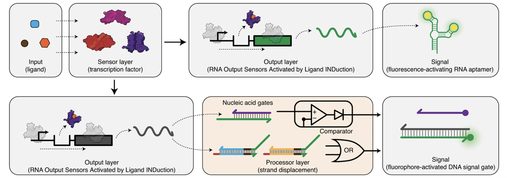

**Cell-free biosensors enhanced by DNA strand displacement circuits.**

Cell-free biosensors are key tools for monitoring human and environmental health. In Jung et al, authors coupled a previously built RNA aptamer-based biosensor platform with toehold-mediated strand displacement to construct tunable circuits with controllable reaction kinetics. Below, I analyze their AND circuit, which is activated when both tetracycline and ZnSO4 are present.

## Looking into the original data frame with glimpse

This data frame has 13 columns which constitute fluorescence measured in time, and three replicate measurements for each: no input, tetracycline (tet) input, ZnSO4 input, and both inputs.

```
## Rows: 121
## Columns: 13
## $ `Time(min)`    <dbl> 0, 1, 2, 3, 4, 5, 6, 7, 8, 9, 10, 11, 12, 13, 14, 15, 1…
## $ no_input_rep_1 <dbl> 0.06474716, 0.06800260, 0.06782175, 0.06944947, 0.06854…
## $ no_input_rep_2 <dbl> 0.06510888, 0.06800260, 0.06764089, 0.06926861, 0.06836…
## $ no_input_rep_3 <dbl> 0.05715112, 0.05986400, 0.05932142, 0.06004485, 0.06058…
## $ tet_rep_1      <dbl> 0.06691746, 0.06944947, 0.07107719, 0.07324749, 0.07270…
## $ tet_rep_2      <dbl> 0.06709831, 0.07071547, 0.06818346, 0.06872604, 0.06981…
## $ tet_rep_3      <dbl> 0.06420459, 0.06601317, 0.06619402, 0.06764089, 0.06818…
## $ ZnSO4_rep_1    <dbl> 0.07017290, 0.07270491, 0.07342834, 0.07469435, 0.07469…
## $ ZnSO4_rep_2    <dbl> 0.05697027, 0.05986400, 0.06004485, 0.06040657, 0.06149…
## $ ZnSO4_rep_3    <dbl> 0.06275772, 0.06619402, 0.06673660, 0.06782175, 0.06709…
## $ both_rep_1     <dbl> 0.06547059, 0.06981118, 0.06944947, 0.07053462, 0.07035…
## $ both_rep_2     <dbl> 0.05588512, 0.05914056, 0.06022571, 0.06221515, 0.06257…
## $ both_rep_3     <dbl> 0.05588512, 0.05877885, 0.05841713, 0.06113000, 0.06058…
```

## Looking into the simplified data frame

Here, all replicates are averaged to simplify plotting in the next step.

```
## Rows: 121
## Columns: 5
## $ Time_min    <dbl> 0, 1, 2, 3, 4, 5, 6, 7, 8, 9, 10, 11, 12, 13, 14, 15, 16, …
## $ av_no_input <dbl> 0.06233572, 0.06528973, 0.06492802, 0.06625431, 0.06583231…
## $ av_tet      <dbl> 0.06607345, 0.06872604, 0.06848489, 0.06987147, 0.07023319…
## $ av_ZnSO4    <dbl> 0.06330030, 0.06625431, 0.06673660, 0.06764089, 0.06776146…
## $ av_both     <dbl> 0.05908028, 0.06257686, 0.06269744, 0.06462659, 0.06450602…
```

## Visualizing fluorescence response of the AND switch to ligands

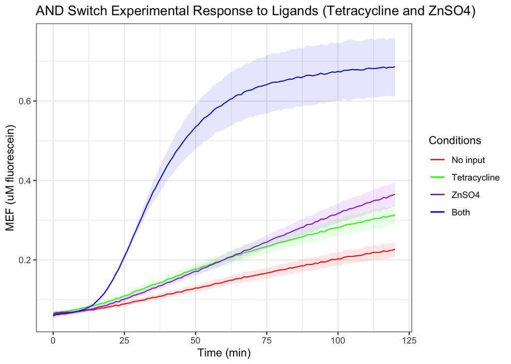

## Looking at solved ODE model data imported from Python

Chemical reactions for the full deterministic model were mapped out in the paper. By making assumptions such as quasi-steady state, authors were able to generate plots using Python’s ODE solver. I reran their code to obtain numerical data. Below you can see what the data looks like.

```
## Rows: 500
## Columns: 5
## $ no_input <dbl> 0.000000000, 0.001792916, 0.005336322, 0.007588456, 0.0085629…
## $ ZnSO4    <dbl> 0.000000000, 0.004499563, 0.006438708, 0.006751646, 0.0070328…
## $ tet      <dbl> 0.00000000, 0.01342572, 0.03540122, 0.05499971, 0.07412672, 0…
## $ both     <dbl> 0.00000000, 0.06817401, 0.20868297, 0.34288113, 0.47269968, 0…
## $ Time     <dbl> 0, 1, 2, 3, 4, 5, 6, 7, 8, 9, 10, 11, 12, 13, 14, 15, 16, 17,…
```

## Plotting solved ODE model to predict circuit behavior

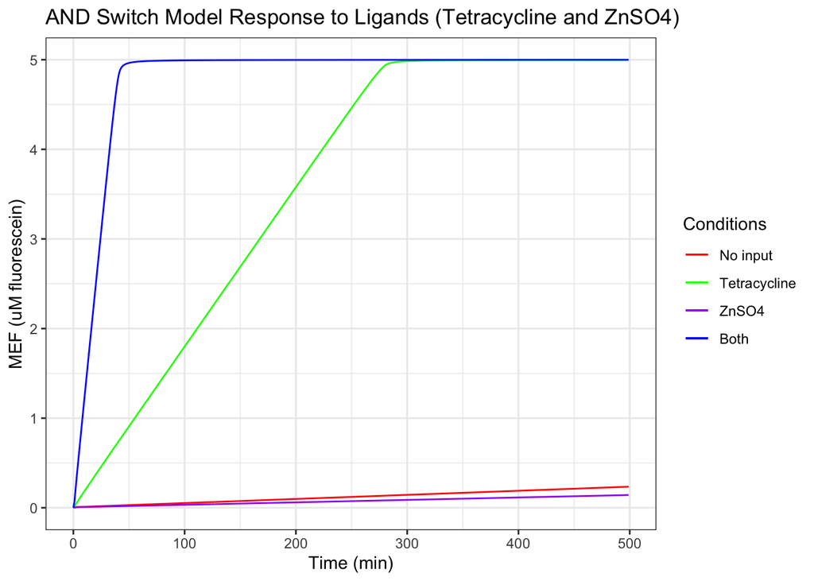

## Overlaying plots for each different condition

Black: Experimental ; Red: Model

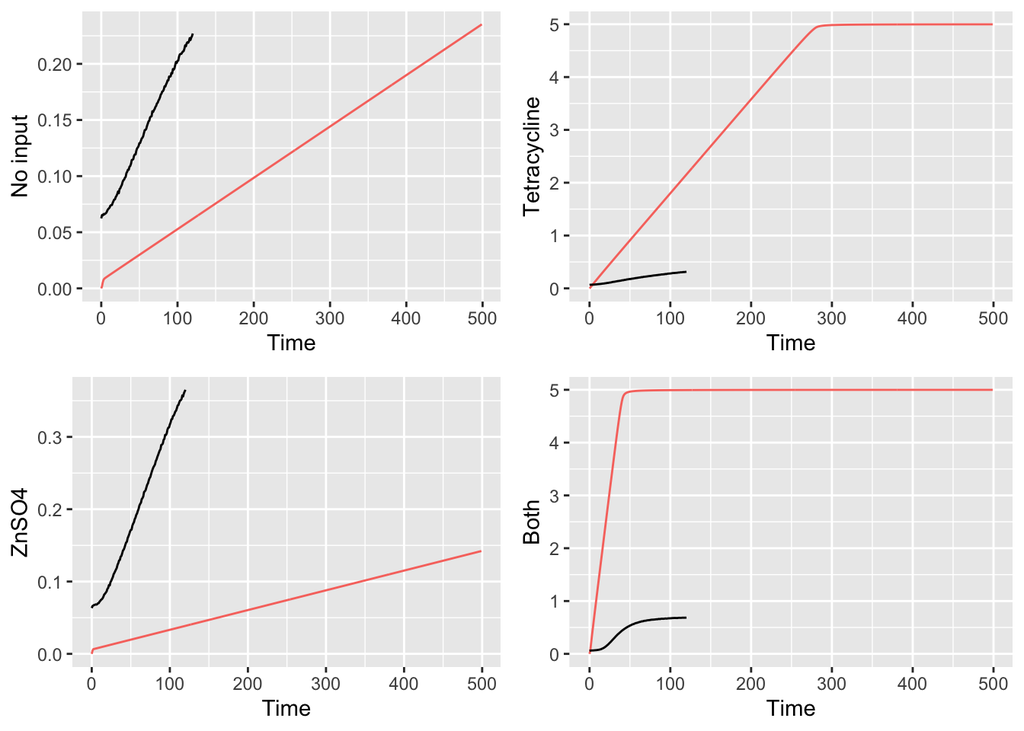

## Conclusion

Tunable gene expression switches with logic gate configurations can effectively control protein output in experimental settings. However, prediction of protein expression is challenging due to assumptions made for easy calculation. A good follow-up to this study would be to track the experimental response for longer to determine if the gate will break after a certain time point.

## Reference

Jung, J.K., Archuleta, C.M., Alam, K.K. et al. Programming cell-free biosensors with DNA strand displacement circuits. Nat Chem Biol 18, 385–393 (2022). https://doi.org/10.1038/s41589-021-00962-9